# Peer Assessment 2

Steven Durham

December 21, 2014

# An Analysis of the Most Destructive Severe Weather Events in the United States (1950-2011)

## Synopsis

Severe weather events can cause public health and economic problems for communities around the country. Many severe events can result in fatalities, injuries, and property damage. Preventing such outcomes to the extent possible is a key concern. This report involves exploring the U.S. National Oceanic and Atmospheric Administration’s (NOAA) storm database, which tracks characteristics of major storms and weather events in the United States, including when and where they occur, as well as estimates of any fatalities, injuries, and property damage. The data analysis attempts to determine which types of events are most harmful with respect to population health, in addition to which types of events have the greatest economic consequences.

## Data Processing

To begin, download the data and read it into R.

```r
if(!file.exists("Storm_Data.csv.bz2")){
        fileUrl <- "https://d396qusza40orc.cloudfront.net/repdata%2Fdata%2FStormData.csv.bz2"
        download.file(fileUrl, "Storm_Data.csv.bz2", method = "curl")
}

storm_data <- read.csv("Storm_Data.csv.bz2")
```

Examine the data to ensure it is the correct dataset and not corrupted in anyway. It’s also good to know what needs to be done to clean the data.

```r
str(storm_data)
```

```
## 'data.frame':    902297 obs. of  37 variables:
##  $ STATE__   : num  1 1 1 1 1 1 1 1 1 1 ...
##  $ BGN_DATE  : Factor w/ 16335 levels "1/1/1966 0:00:00",..: 6523 6523 4242 11116 2224 2224 2260 383 3980 3980 ...
##  $ BGN_TIME  : Factor w/ 3608 levels "00:00:00 AM",..: 272 287 2705 1683 2584 3186 242 1683 3186 3186 ...
##  $ TIME_ZONE : Factor w/ 22 levels "ADT","AKS","AST",..: 7 7 7 7 7 7 7 7 7 7 ...
##  $ COUNTY    : num  97 3 57 89 43 77 9 123 125 57 ...
##  $ COUNTYNAME: Factor w/ 29601 levels "","5NM E OF MACKINAC BRIDGE TO PRESQUE ISLE LT MI",..: 13513 1873 4598 10592 4372 10094 1973 23873 24418 4598 ...
##  $ STATE     : Factor w/ 72 levels "AK","AL","AM",..: 2 2 2 2 2 2 2 2 2 2 ...
##  $ EVTYPE    : Factor w/ 985 levels "   HIGH SURF ADVISORY",..: 834 834 834 834 834 834 834 834 834 834 ...
##  $ BGN_RANGE : num  0 0 0 0 0 0 0 0 0 0 ...
##  $ BGN_AZI   : Factor w/ 35 levels "","  N"," NW",..: 1 1 1 1 1 1 1 1 1 1 ...
##  $ BGN_LOCATI: Factor w/ 54429 levels ""," Christiansburg",..: 1 1 1 1 1 1 1 1 1 1 ...
##  $ END_DATE  : Factor w/ 6663 levels "","1/1/1993 0:00:00",..: 1 1 1 1 1 1 1 1 1 1 ...
##  $ END_TIME  : Factor w/ 3647 levels ""," 0900CST",..: 1 1 1 1 1 1 1 1 1 1 ...
##  $ COUNTY_END: num  0 0 0 0 0 0 0 0 0 0 ...
```

[output cut: 23 more lines]

The EVTYPE variable contains the information about the weather events. But there are many synonymous observations and it is not in a consistent case. Clean the data by combining similar names to certain weather events, and making all of the observations in the EVTYPE variable upper case.

```r
clean_EVTYPE_data <- as.character(toupper(storm_data$EVTYPE))

clean_EVTYPE_data[grepl("RAIN",clean_EVTYPE_data)] <- "HEAVY RAIN"
clean_EVTYPE_data[grepl("WINTER",clean_EVTYPE_data)] <- "WINTER STORM"
clean_EVTYPE_data[grepl("WINTRY",clean_EVTYPE_data)] <- "WINTER STORM"
clean_EVTYPE_data[grepl("BLIZZARD",clean_EVTYPE_data)] <- "BLIZZARD"
clean_EVTYPE_data[grepl("TSTM",clean_EVTYPE_data)] <- "TROPICAL STORM"
clean_EVTYPE_data[grepl("TROPICAL",clean_EVTYPE_data)] <- "TROPICAL STORM"
clean_EVTYPE_data[grepl("THUN?D.",clean_EVTYPE_data)] <- "THUNDERSTORM WIND"
clean_EVTYPE_data[grepl("TH?UN.",clean_EVTYPE_data)] <- "THUNDERSTORM WIND"
clean_EVTYPE_data[grepl("HAIL",clean_EVTYPE_data)] <- "HAIL"
clean_EVTYPE_data[grepl("FLOOD",clean_EVTYPE_data)] <- "FLOOD"
clean_EVTYPE_data[grepl("DAM BREAK",clean_EVTYPE_data)] <- "FLOOD"
clean_EVTYPE_data[grepl("HURRICANE",clean_EVTYPE_data)] <- "HURRICANE (TYPHOON)"
clean_EVTYPE_data[grepl("TYPHOON",clean_EVTYPE_data)] <- "HURRICANE (TYPHOON)"
clean_EVTYPE_data[grepl("SNOW",clean_EVTYPE_data)] <- "HEAVY SNOW"
clean_EVTYPE_data[grepl("COLD",clean_EVTYPE_data)] <- "COLD/WIND CHILL"
clean_EVTYPE_data[grepl("COOL",clean_EVTYPE_data)] <- "COLD/WIND CHILL"
clean_EVTYPE_data[grepl("CHILL",clean_EVTYPE_data)] <- "COLD/WIND CHILL"
clean_EVTYPE_data[grepl("TORNADO",clean_EVTYPE_data)] <- "TORNADO"
clean_EVTYPE_data[grepl("TORNDAO",clean_EVTYPE_data)] <- "TORNADO"
clean_EVTYPE_data[grepl("FIRE",clean_EVTYPE_data)] <- "WILDFIRE"
clean_EVTYPE_data[grepl("TSUNAMI",clean_EVTYPE_data)] <- "TSUNAMI"
clean_EVTYPE_data[grepl("AVALANC.",clean_EVTYPE_data)] <- "AVALANCHE"
clean_EVTYPE_data[grepl("FREEZ.",clean_EVTYPE_data)] <- "WINTER WEATHER"
clean_EVTYPE_data[grepl("^IC[EY].?",clean_EVTYPE_data)] <- "ICE STORM"
clean_EVTYPE_data[grepl(" ICE",clean_EVTYPE_data)] <- "ICE STORM"
clean_EVTYPE_data[grepl("HEAT",clean_EVTYPE_data)] <- "HEAT"
clean_EVTYPE_data[grepl("^UNSEASONABLY",clean_EVTYPE_data)] <- "HEAT"
clean_EVTYPE_data[grepl("^RIP>?",clean_EVTYPE_data)] <- "RIP CURRENT"
clean_EVTYPE_data[grepl("^URBAN.?",clean_EVTYPE_data)] <- "FLOOD"
clean_EVTYPE_data[grepl("WATERSPOUT.",clean_EVTYPE_data)] <- "WATERSPOUT"
clean_EVTYPE_data[grepl("^STRONG WIND.",clean_EVTYPE_data)] <- "STRONG WIND"
clean_EVTYPE_data[grepl("^STORM SURGE.",clean_EVTYPE_data)] <- "STORM SURGE"
clean_EVTYPE_data[grepl("^WIND.?",clean_EVTYPE_data)] <- "STRONG WIND"
clean_EVTYPE_data[grepl("^LIG[HN]T",clean_EVTYPE_data)] <- "LIGHTNING"
clean_EVTYPE_data[grepl("HIGH WIND.",clean_EVTYPE_data)] <- "HIGH WIND"
clean_EVTYPE_data[grepl("MUD",clean_EVTYPE_data)] <- "DEBRIS FLOW"
clean_EVTYPE_data[grepl("LANDSLIDE.?",clean_EVTYPE_data)] <- "DEBRIS FLOW"
clean_EVTYPE_data[grepl("SURF",clean_EVTYPE_data)] <- "HIGH SURF"
clean_EVTYPE_data[grepl("SLEET.?",clean_EVTYPE_data)] <- "SLEET"
clean_EVTYPE_data[grepl("PRECIPITATION",clean_EVTYPE_data)] <- "HEAVY RAIN"
clean_EVTYPE_data[grepl("DUST",clean_EVTYPE_data)] <- "DUST"
clean_EVTYPE_data[grepl("GLAZE",clean_EVTYPE_data)] <- "ICE STORM"
clean_EVTYPE_data[grepl("SURGE",clean_EVTYPE_data)] <- "STORM SURGE/TIDE"

storm_data$EVTYPE <- clean_EVTYPE_data
```

Subset the data by creating two new variables, one that contains variables pertaining to public health (FATALITIES and INJURIES), and one that contains variables pertaining to property and crop damage (PROPDMG and CROPDMG).

```r
health_storm_data <- storm_data[,c("EVTYPE","FATALITIES","INJURIES")]
economic_storm_data <- storm_data[,c("EVTYPE","PROPDMG","CROPDMG")]
```

Aggregate the data by event type to find out which events have caused the most injury, loss of life, and damage between the years 1950-2011.

```r
injuries <- aggregate(health_storm_data$INJURIES, list(Event = health_storm_data$EVTYPE), sum, na.rm = TRUE)
most_injuries <- head(injuries[order(injuries$x, decreasing=TRUE), ],10)

fatalities <- aggregate(health_storm_data$FATALITIES, list(Event = health_storm_data$EVTYPE), sum, na.rm = TRUE)
most_fatalities <- head(fatalities[order(fatalities$x, decreasing=TRUE), ], 10)

combined_injuries_fatalities <- aggregate(health_storm_data$INJURIES+health_storm_data$FATALITIES, list(Event = health_storm_data$EVTYPE), sum, na.rm = TRUE)
most_combined_injuries_fatalities <- head(combined_injuries_fatalities[order(combined_injuries_fatalities$x, decreasing=TRUE), ], 10)

property_damage <- aggregate(economic_storm_data$PROPDMG, list(Event = economic_storm_data$EVTYPE), sum, na.rm = TRUE)
most_property_damage <- head(property_damage[order(property_damage$x, decreasing=TRUE), ],10)

crop_damage <- aggregate(economic_storm_data$CROPDMG, list(Event = economic_storm_data$EVTYPE), sum, na.rm = TRUE)
most_crop_damage <- head(crop_damage[order(crop_damage$x, decreasing=TRUE), ], 10)

combined_property_crop_damage <- aggregate(economic_storm_data$PROPDMG+economic_storm_data$CROPDMG, list(Event = economic_storm_data$EVTYPE), sum, na.rm = TRUE)
most_combined_property_crop_damage <- head(combined_property_crop_damage[order(combined_property_crop_damage$x, decreasing=TRUE), ], 10)
```

## Results

Below are three bar charts showing the top 10 most dangerous weather events for human safety in the United States.

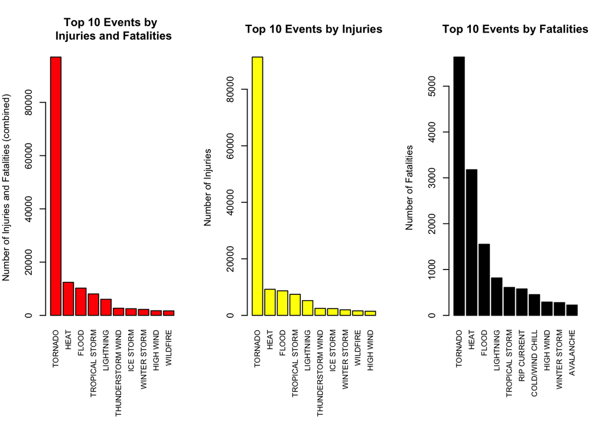

```r
par(mfrow=c(1,3))
par(mar=c(10,4,5,2))
barplot(most_combined_injuries_fatalities$x, names.arg=most_combined_injuries_fatalities$Event, cex.names=0.8, las=3, main="Top 10 Events by \n Injuries and Fatalities", ylab="Number of Injuries and Fatalities (combined)", col="red")
barplot(most_injuries$x, names.arg=most_injuries$Event, cex.names=0.8, las=3, main="Top 10 Events by Injuries", ylab="Number of Injuries", col="yellow")
barplot(most_fatalities$x, names.arg=most_fatalities$Event, cex.names=0.8, las=3, main="Top 10 Events by Fatalities", ylab="Number of Fatalities", col="black")
```

Below are three bar charts showing the top 10 most economically destructive weather events in the United States.

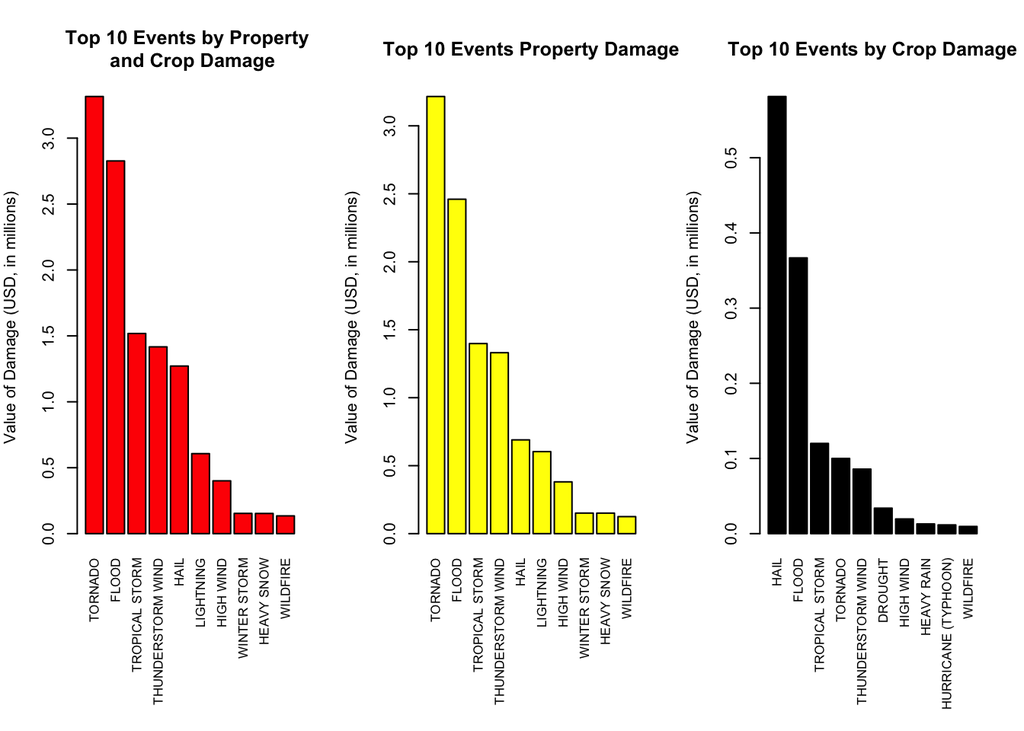

```r
par(mfrow=c(1,3))
par(mar=c(10,4,5,2))
barplot(most_combined_property_crop_damage$x/1000000, names.arg=most_combined_property_crop_damage$Event, cex.names=0.8, las=3, main="Top 10 Events by Property \n and Crop Damage", ylab="Value of Damage (USD, in millions)", col="red")
barplot(most_property_damage$x/1000000, names.arg=most_property_damage$Event, cex.names=0.8, las=3, main="Top 10 Events Property Damage", ylab="Value of Damage (USD, in millions)", col="yellow")
barplot(most_crop_damage$x/1000000, names.arg=most_crop_damage$Event, cex.names=0.8, las=3, main="Top 10 Events by Crop Damage", ylab="Value of Damage (USD, in millions)", col="black")
```

*Tornados cause the most property damage, followed by flooding and tropical storms. Interestingly, tornados are not nearly as destructive to crops as other events, which is surprising given that most tornados occur in “America’s Breadbasket”. The three most costly weather events when it comes to crop damage are hail, flooding, and tropical storms. However, tornados cause so much property damage, that when taken in total, tornados cause the most economic damage of any weather event.*